# Data 621

Cesar Espitia HW #3

7/1/2018

## Abstract

### Keywords: crime, data621

## Data Exploration

```r
knitr::opts_chunk$set(echo = TRUE)
library(e1071)
library(dplyr)
```

```r
library(purrr)
library(tidyr)
library(ggplot2)
library(corrplot)
library(FactoMineR)
library(VIF)
library(knitr)
library(kableExtra)
library(Hmisc)
library(pROC)
# read data
train = read.csv(file="data/crime-training-data.csv")
train2<-train
dim(train)
```

```
## [1] 466  14
```

```r
#check data
summary(train) %>% kable() %>% kable_styling()
```

[output not shown]

[output not shown]

[output not shown]

[output not shown]

[output not shown]

[output not shown]

[output not shown]

[output not shown]

[output not shown]

[output not shown]

[output not shown]

[output not shown]

[output not shown]

[output not shown]

Min. : 0.00

Min. : 0.460

Min. :0.00000

Min. :0.3890

Min. :3.863

Min. : 2.90

Min. : 1.130

Min. : 1.00

Min. :187.0

Min. :12.6

Min. : 0.32

Min. : 1.730

Min. : 5.00

Min. :0.0000

1st Qu.: 0.00

1st Qu.: 5.145

1st Qu.:0.00000

1st Qu.:0.4480

1st Qu.:5.887

1st Qu.: 43.88

1st Qu.: 2.101

1st Qu.: 4.00

1st Qu.:281.0

1st Qu.:16.9

1st Qu.:375.61

1st Qu.: 7.043

1st Qu.:17.02

1st Qu.:0.0000

Median : 0.00

Median : 9.690

Median :0.00000

Median :0.5380

Median :6.210

Median : 77.15

Median : 3.191

Median : 5.00

Median :334.5

Median :18.9

Median :391.34

Median :11.350

Median :21.20

Median :0.0000

Mean : 11.58

Mean :11.105

Mean :0.07082

Mean :0.5543

Mean :6.291

Mean : 68.37

Mean : 3.796

Mean : 9.53

Mean :409.5

Mean :18.4

Mean :357.12

Mean :12.631

Mean :22.59

Mean :0.4914

3rd Qu.: 16.25

3rd Qu.:18.100

3rd Qu.:0.00000

3rd Qu.:0.6240

3rd Qu.:6.630

3rd Qu.: 94.10

3rd Qu.: 5.215

3rd Qu.:24.00

3rd Qu.:666.0

3rd Qu.:20.2

3rd Qu.:396.24

3rd Qu.:16.930

3rd Qu.:25.00

3rd Qu.:1.0000

Max. :100.00

Max. :27.740

Max. :1.00000

Max. :0.8710

Max. :8.780

Max. :100.00

Max. :12.127

Max. :24.00

Max. :711.0

Max. :22.0

Max. :396.90

Max. :37.970

Max. :50.00

Max. :1.0000

```r
sapply(train, function(x) sum(is.na(x)))
```

```
##      zn   indus    chas     nox      rm     age     dis     rad     tax
##       0       0       0       0       0       0       0       0       0
## ptratio   black   lstat    medv  target
##       0       0       0       0       0
```

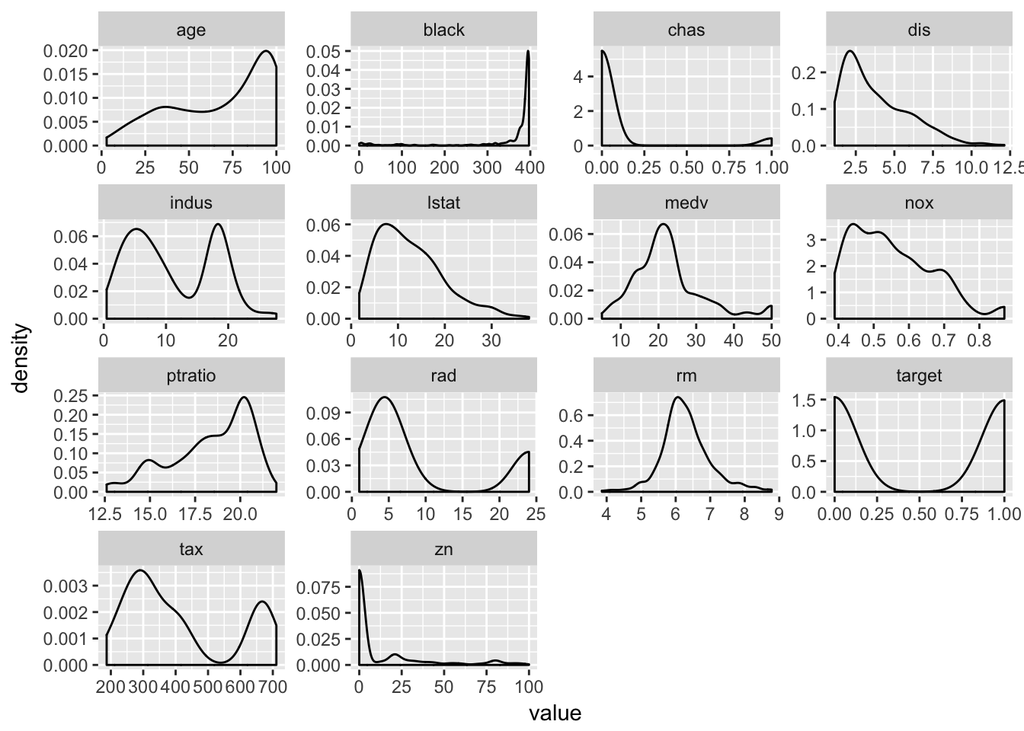

```r
ntrain<-select_if(train, is.numeric)
ntrain %>%
  keep(is.numeric) %>%                     # Keep only numeric columns
  gather() %>%                             # Convert to key-value pairs
  ggplot(aes(value)) +                     # Plot the values
    facet_wrap(~ key, scales = "free") +   # In separate panels
    geom_density()
```

```r
rcorr(as.matrix(train))
```

```
##            zn indus  chas   nox    rm   age   dis   rad   tax ptratio
## zn       1.00 -0.54 -0.04 -0.52  0.32 -0.57  0.66 -0.32 -0.32   -0.39
## indus   -0.54  1.00  0.06  0.76 -0.39  0.64 -0.70  0.60  0.73    0.39
## chas    -0.04  0.06  1.00  0.10  0.09  0.08 -0.10 -0.02 -0.05   -0.13
## nox     -0.52  0.76  0.10  1.00 -0.30  0.74 -0.77  0.60  0.65    0.18
## rm       0.32 -0.39  0.09 -0.30  1.00 -0.23  0.20 -0.21 -0.30   -0.36
## age     -0.57  0.64  0.08  0.74 -0.23  1.00 -0.75  0.46  0.51    0.26
## dis      0.66 -0.70 -0.10 -0.77  0.20 -0.75  1.00 -0.49 -0.53   -0.23
## rad     -0.32  0.60 -0.02  0.60 -0.21  0.46 -0.49  1.00  0.91    0.47
## tax     -0.32  0.73 -0.05  0.65 -0.30  0.51 -0.53  0.91  1.00    0.47
## ptratio -0.39  0.39 -0.13  0.18 -0.36  0.26 -0.23  0.47  0.47    1.00
## black    0.18 -0.36  0.04 -0.38  0.13 -0.27  0.29 -0.45 -0.44   -0.18
## lstat   -0.43  0.61 -0.05  0.60 -0.63  0.61 -0.51  0.50  0.56    0.38
## medv     0.38 -0.50  0.16 -0.43  0.71 -0.38  0.26 -0.40 -0.49   -0.52
## target  -0.43  0.60  0.08  0.73 -0.15  0.63 -0.62  0.63  0.61    0.25
##         black lstat  medv target
## zn       0.18 -0.43  0.38  -0.43
## indus   -0.36  0.61 -0.50   0.60
## chas     0.04 -0.05  0.16   0.08
## nox     -0.38  0.60 -0.43   0.73
## rm       0.13 -0.63  0.71  -0.15
## age     -0.27  0.61 -0.38   0.63
## dis      0.29 -0.51  0.26  -0.62
## rad     -0.45  0.50 -0.40   0.63
## tax     -0.44  0.56 -0.49   0.61
## ptratio -0.18  0.38 -0.52   0.25
## black    1.00 -0.35  0.33  -0.35
## lstat   -0.35  1.00 -0.74   0.47
## medv     0.33 -0.74  1.00  -0.27
## target  -0.35  0.47 -0.27   1.00
##
## n= 466
##
##
## P
##         zn     indus  chas   nox    rm     age    dis    rad    tax
## zn             0.0000 0.3870 0.0000 0.0000 0.0000 0.0000 0.0000 0.0000
## indus   0.0000        0.1874 0.0000 0.0000 0.0000 0.0000 0.0000 0.0000
## chas    0.3870 0.1874        0.0355 0.0509 0.0890 0.0372 0.7321 0.3138
## nox     0.0000 0.0000 0.0355        0.0000 0.0000 0.0000 0.0000 0.0000
```

[output cut: 10 more lines]

```
##         ptratio black  lstat  medv   target
## zn      0.0000  0.0000 0.0000 0.0000 0.0000
## indus   0.0000  0.0000 0.0000 0.0000 0.0000
## chas    0.0054  0.3384 0.2679 0.0005 0.0843
## nox     0.0001  0.0000 0.0000 0.0000 0.0000
## rm      0.0000  0.0041 0.0000 0.0000 0.0010
## age     0.0000  0.0000 0.0000 0.0000 0.0000
## dis     0.0000  0.0000 0.0000 0.0000 0.0000
## rad     0.0000  0.0000 0.0000 0.0000 0.0000
## tax     0.0000  0.0000 0.0000 0.0000 0.0000
## ptratio         0.0000 0.0000 0.0000 0.0000
## black   0.0000         0.0000 0.0000 0.0000
## lstat   0.0000  0.0000        0.0000 0.0000
## medv    0.0000  0.0000 0.0000        0.0000
## target  0.0000  0.0000 0.0000 0.0000
```

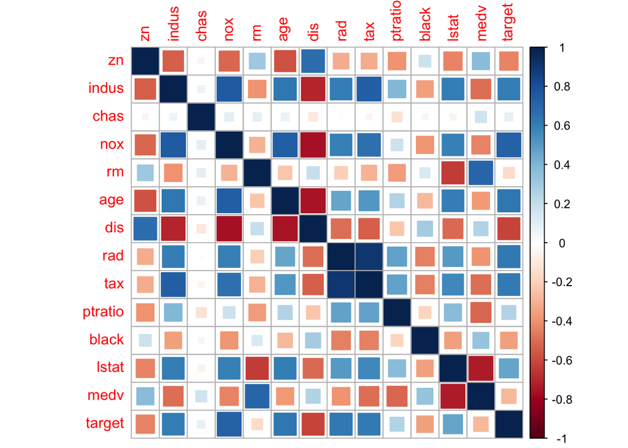

```r
corrplot(cor(train), method="square")
```

```r
# correlation test 1
cor.test(train$rad,train$tax,method="pearson")
```

```
##
##  Pearson's product-moment correlation
##
## data:  train$rad and train$tax
## t = 46.239, df = 464, p-value < 2.2e-16
## alternative hypothesis: true correlation is not equal to 0
## 95 percent confidence interval:
##  0.8888115 0.9214292
## sample estimates:
##       cor
## 0.9064632
```

```r
#significant ignore
```

## Data Preparation

```r
# transform data using log for skewed

train$zn <- log(train$zn+1)
train$black <- log(train$black+1)
train$chas <- log(train$chas+1)


#remove rad per correlation in prior section

train <- train[, !(colnames(train) %in% c("rad"))]

#create variable
train$new <- train$tax / (train$medv*10)

rcorr(as.matrix(train))
```

```
##            zn indus  chas   nox    rm   age   dis   tax ptratio black
## zn       1.00 -0.60 -0.04 -0.55  0.34 -0.58  0.69 -0.40   -0.46  0.17
## indus   -0.60  1.00  0.06  0.76 -0.39  0.64 -0.70  0.73    0.39 -0.28
## chas    -0.04  0.06  1.00  0.10  0.09  0.08 -0.10 -0.05   -0.13  0.05
## nox     -0.55  0.76  0.10  1.00 -0.30  0.74 -0.77  0.65    0.18 -0.29
## rm       0.34 -0.39  0.09 -0.30  1.00 -0.23  0.20 -0.30   -0.36  0.09
## age     -0.58  0.64  0.08  0.74 -0.23  1.00 -0.75  0.51    0.26 -0.21
## dis      0.69 -0.70 -0.10 -0.77  0.20 -0.75  1.00 -0.53   -0.23  0.23
## tax     -0.40  0.73 -0.05  0.65 -0.30  0.51 -0.53  1.00    0.47 -0.38
## ptratio -0.46  0.39 -0.13  0.18 -0.36  0.26 -0.23  0.47    1.00 -0.18
## black    0.17 -0.28  0.05 -0.29  0.09 -0.21  0.23 -0.38   -0.18  1.00
## lstat   -0.46  0.61 -0.05  0.60 -0.63  0.61 -0.51  0.56    0.38 -0.28
## medv     0.40 -0.50  0.16 -0.43  0.71 -0.38  0.26 -0.49   -0.52  0.29
## target  -0.47  0.60  0.08  0.73 -0.15  0.63 -0.62  0.61    0.25 -0.28
## new     -0.37  0.62 -0.11  0.59 -0.39  0.49 -0.48  0.80    0.45 -0.41
##         lstat  medv target   new
## zn      -0.46  0.40  -0.47 -0.37
## indus    0.61 -0.50   0.60  0.62
## chas    -0.05  0.16   0.08 -0.11
## nox      0.60 -0.43   0.73  0.59
## rm      -0.63  0.71  -0.15 -0.39
## age      0.61 -0.38   0.63  0.49
## dis     -0.51  0.26  -0.62 -0.48
## tax      0.56 -0.49   0.61  0.80
## ptratio  0.38 -0.52   0.25  0.45
## black   -0.28  0.29  -0.28 -0.41
## lstat    1.00 -0.74   0.47  0.72
## medv    -0.74  1.00  -0.27 -0.69
## target   0.47 -0.27   1.00  0.49
## new      0.72 -0.69   0.49  1.00
##
## n= 466
##
##
## P
##         zn     indus  chas   nox    rm     age    dis    tax    ptratio
## zn             0.0000 0.4059 0.0000 0.0000 0.0000 0.0000 0.0000 0.0000
## indus   0.0000        0.1874 0.0000 0.0000 0.0000 0.0000 0.0000 0.0000
## chas    0.4059 0.1874        0.0355 0.0509 0.0890 0.0372 0.3138 0.0054
## nox     0.0000 0.0000 0.0355        0.0000 0.0000 0.0000 0.0000 0.0001
```

[output cut: 10 more lines]

```
##         black  lstat  medv   target new
## zn      0.0002 0.0000 0.0000 0.0000 0.0000
## indus   0.0000 0.0000 0.0000 0.0000 0.0000
## chas    0.2570 0.2679 0.0005 0.0843 0.0223
## nox     0.0000 0.0000 0.0000 0.0000 0.0000
## rm      0.0642 0.0000 0.0000 0.0010 0.0000
## age     0.0000 0.0000 0.0000 0.0000 0.0000
## dis     0.0000 0.0000 0.0000 0.0000 0.0000
## tax     0.0000 0.0000 0.0000 0.0000 0.0000
## ptratio 0.0000 0.0000 0.0000 0.0000 0.0000
## black          0.0000 0.0000 0.0000 0.0000
## lstat   0.0000        0.0000 0.0000 0.0000
## medv    0.0000 0.0000        0.0000 0.0000
## target  0.0000 0.0000 0.0000        0.0000
## new     0.0000 0.0000 0.0000 0.0000
```

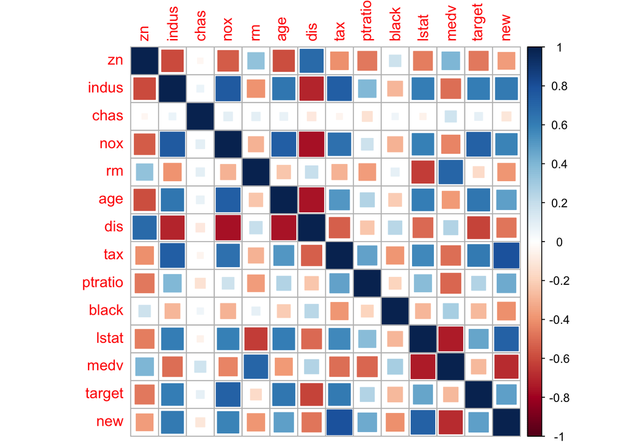

```r
corrplot(cor(train), method="square")
```

## Build Models

```r
#MODEL 1
logit <- glm(target ~ ., data=train, family = "binomial" (link="logit"))
summary(logit)
```

```
##
## Call:
## glm(formula = target ~ ., family = binomial(link = "logit"),
##     data = train)
##
## Deviance Residuals:
##     Min       1Q   Median       3Q      Max
## -2.1097  -0.2702  -0.0188   0.1965   3.5752
##
## Coefficients:
##               Estimate Std. Error z value Pr(>|z|)
## (Intercept) -33.029280   8.409645  -3.928 8.58e-05 ***
## zn           -0.681913   0.248420  -2.745 0.006051 **
## indus        -0.152009   0.049530  -3.069 0.002148 **
## chas          2.500407   0.970167   2.577 0.009958 **
## nox          51.588709   7.272073   7.094 1.30e-12 ***
## rm           -0.093566   0.620763  -0.151 0.880190
## age           0.024907   0.012537   1.987 0.046958 *
## dis           0.922461   0.220580   4.182 2.89e-05 ***
## tax           0.008238   0.002404   3.427 0.000611 ***
## ptratio       0.298144   0.113540   2.626 0.008642 **
## black        -1.785172   1.031215  -1.731 0.083428 .
## lstat         0.087574   0.052940   1.654 0.098088 .
## medv          0.181463   0.061169   2.967 0.003011 **
## new          -0.425892   0.194726  -2.187 0.028732 *
## ---
## Signif. codes:  0 '***' 0.001 '**' 0.01 '*' 0.05 '.' 0.1 ' ' 1
##
## (Dispersion parameter for binomial family taken to be 1)
##
##     Null deviance: 645.88  on 465  degrees of freedom
## Residual deviance: 223.59  on 452  degrees of freedom
## AIC: 251.59
##
## Number of Fisher Scoring iterations: 8
```

```r
exp(logit$coefficients)
```

```
##  (Intercept)           zn        indus         chas          nox
## 4.524451e-15 5.056487e-01 8.589803e-01 1.218746e+01 2.539168e+22
##           rm          age          dis          tax      ptratio
## 9.106778e-01 1.025219e+00 2.515473e+00 1.008272e+00 1.347356e+00
##        black        lstat         medv          new
## 1.677682e-01 1.091523e+00 1.198970e+00 6.531872e-01
```

```r
logitscalar <- mean(dlogis(predict(logit, type = "link")))
logitscalar * coef(logit)
```

```
##   (Intercept)            zn         indus          chas           nox
## -2.5169305639 -0.0519638271 -0.0115835637  0.1905385638  3.9312148611
##            rm           age           dis           tax       ptratio
## -0.0071300236  0.0018979633  0.0702942880  0.0006277545  0.0227194938
##         black         lstat          medv           new
## -0.1360354839  0.0066733801  0.0138280224 -0.0324542205
```

```r
confint.default(logit)
```

```
##                     2.5 %       97.5 %
## (Intercept) -4.951188e+01 -16.54667903
## zn          -1.168807e+00  -0.19501926
## indus       -2.490869e-01  -0.05493168
## chas         5.989156e-01   4.40189905
## nox          3.733571e+01  65.84171053
## rm          -1.310238e+00   1.12310610
## age          3.349061e-04   0.04947844
## dis          4.901328e-01   1.35478874
## tax          3.526349e-03   0.01294950
## ptratio      7.560983e-02   0.52067879
## black       -3.806316e+00   0.23597177
## lstat       -1.618741e-02   0.19133483
## medv         6.157454e-02   0.30135134
## new         -8.075467e-01  -0.04423648
```

```r
predlogit <- predict(logit, type="response")
train2$pred1 <- predict(logit, type="response")
summary(predlogit)
```

```
##      Min.   1st Qu.    Median      Mean   3rd Qu.      Max.
## 0.0001109 0.0309268 0.4822112 0.4914163 0.9714183 1.0000000
```

```r
table(true = train$target, pred = round(fitted(logit)))
```

```
##     pred
## true   0   1
##    0 213  24
##    1  22 207
```

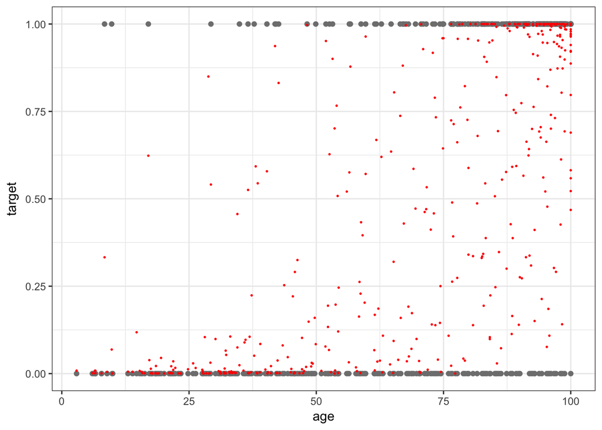

```r
#plots for Model 1
ggplot(data = train, aes(x = age, y = target)) +
    geom_point(color = 'grey50') +
    geom_point(data = train2, aes(x = age, y = pred1), color = 'red', size = 0.3) +
    theme_bw()
```

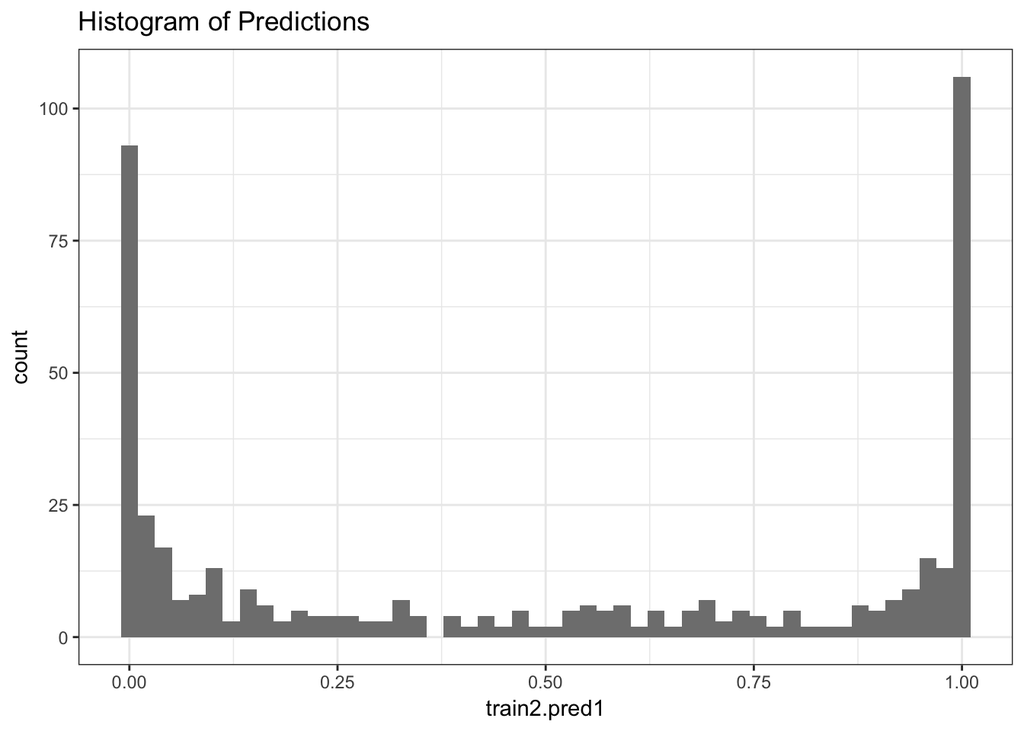

```r
data.frame(train2$pred1) %>%
    ggplot(aes(x = train2.pred1)) +
    geom_histogram(bins = 50, fill = 'grey50') +
    labs(title = 'Histogram of Predictions') +
    theme_bw()
```

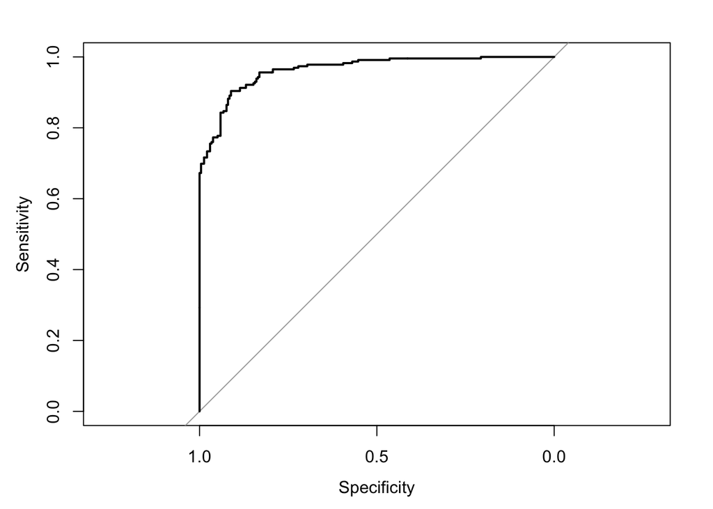

```r
plot.roc(train$target, train2$pred1)
```

```r
#extract variables that are significant and rerun model
sigvars <- data.frame(summary(logit)$coef[summary(logit)$coef[,4] <= .05, 4])
sigvars <- add_rownames(sigvars, "vars")
colist<-dplyr::pull(sigvars, vars)
colist<-colist[2:11]

idx <- match(colist, names(train))
trainmod2 <- cbind(train[,idx], train2['target'])

#MODEL 2
logit2 <- glm(target ~ ., data=trainmod2, family = "binomial" (link="logit"))
summary(logit2)
```

```
##
## Call:
## glm(formula = target ~ ., family = binomial(link = "logit"),
##     data = trainmod2)
##
## Deviance Residuals:
##     Min       1Q   Median       3Q      Max
## -2.3341  -0.3000  -0.0271   0.2216   3.5120
##
## Coefficients:
##               Estimate Std. Error z value Pr(>|z|)
## (Intercept) -40.559519   5.624242  -7.212 5.53e-13 ***
## zn           -0.570579   0.227004  -2.514 0.011953 *
## indus        -0.141446   0.049062  -2.883 0.003939 **
## chas          2.791745   0.970675   2.876 0.004026 **
## nox          48.903546   6.885627   7.102 1.23e-12 ***
## age           0.027388   0.010057   2.723 0.006465 **
## dis           0.804755   0.203539   3.954 7.69e-05 ***
## tax           0.008311   0.002432   3.418 0.000632 ***
## ptratio       0.289929   0.107363   2.700 0.006925 **
## medv          0.130716   0.033228   3.934 8.36e-05 ***
## new          -0.280439   0.208775  -1.343 0.179187
## ---
## Signif. codes:  0 '***' 0.001 '**' 0.01 '*' 0.05 '.' 0.1 ' ' 1
##
## (Dispersion parameter for binomial family taken to be 1)
##
##     Null deviance: 645.88  on 465  degrees of freedom
## Residual deviance: 234.26  on 455  degrees of freedom
## AIC: 256.26
##
## Number of Fisher Scoring iterations: 7
```

```r
exp(logit2$coefficients)
```

```
##  (Intercept)           zn        indus         chas          nox
## 2.427866e-18 5.651983e-01 8.681022e-01 1.630945e+01 1.731970e+21
##          age          dis          tax      ptratio         medv
## 1.027766e+00 2.236148e+00 1.008346e+00 1.336332e+00 1.139644e+00
##          new
## 7.554517e-01
```

```r
logit2scalar <- mean(dlogis(predict(logit2, type = "link")))
logit2scalar * coef(logit2)
```

```
##   (Intercept)            zn         indus          chas           nox
## -3.2356595453 -0.0455182453 -0.0112839288  0.2227131005  3.9013092282
##           age           dis           tax       ptratio          medv
##  0.0021848724  0.0641997863  0.0006630314  0.0231292172  0.0104279150
##           new
## -0.0223722213
```

```r
predlogit2 <- predict(logit2, type="response")
train2$pred2 <- predict(logit2, type="response")

summary(predlogit2)
```

```
##      Min.   1st Qu.    Median      Mean   3rd Qu.      Max.
## 0.0002271 0.0330183 0.4686400 0.4914163 0.9662585 0.9999995
```

```r
table(true = train$target, pred = round(fitted(logit2)))
```

```
##     pred
## true   0   1
##    0 214  23
##    1  25 204
```

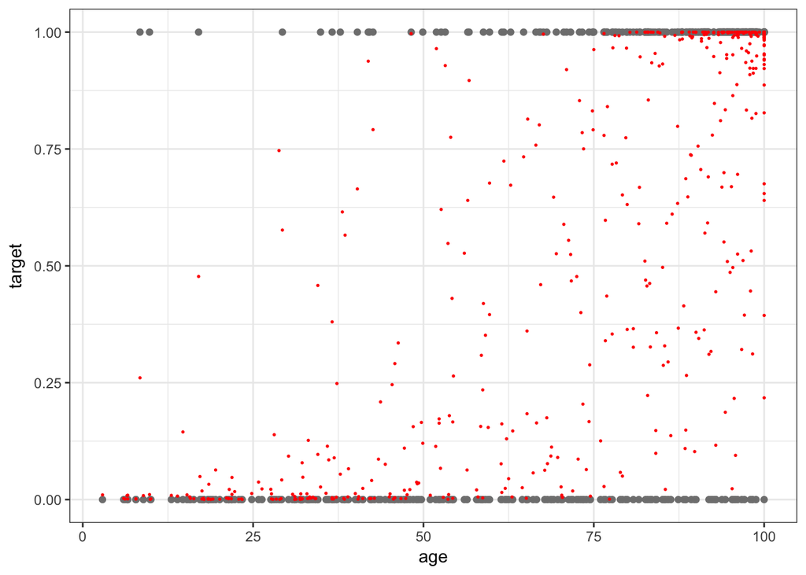

```r
#plots for Model 2
ggplot(data = train, aes(x = age, y = target)) +
    geom_point(color = 'grey50') +
    geom_point(data = train2, aes(x = age, y = pred2), color = 'red', size = 0.3) +
    theme_bw()
```

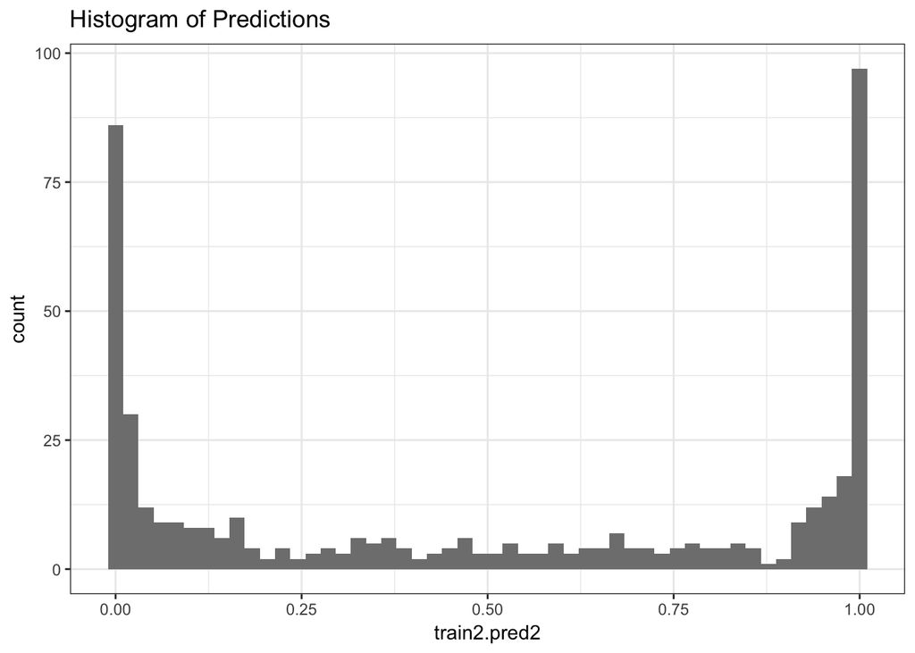

```r
data.frame(train2$pred2) %>%
    ggplot(aes(x = train2.pred2)) +
    geom_histogram(bins = 50, fill = 'grey50') +
    labs(title = 'Histogram of Predictions') +
    theme_bw()
```

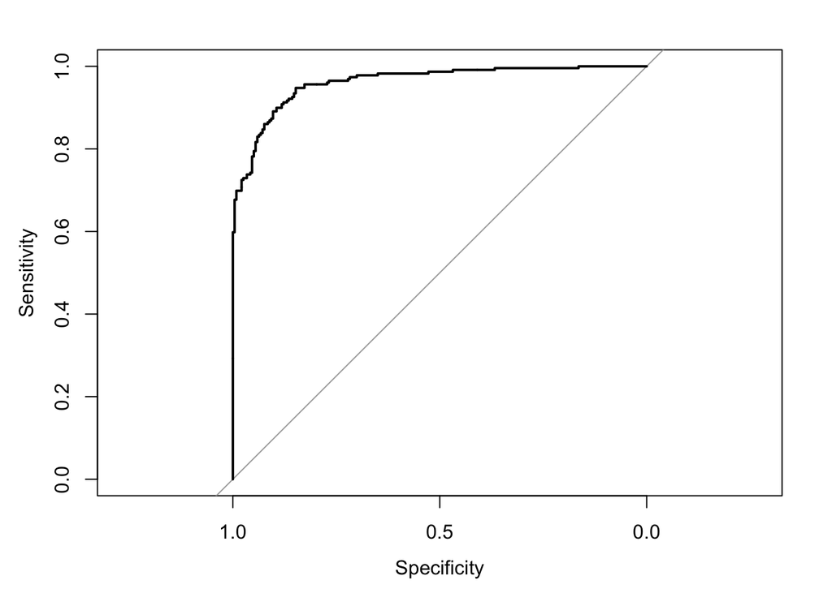

```r
plot.roc(train$target, train2$pred2)
```

```r
#MODEL 3
#PC Model no racial bias
logit3<-model <- glm(target ~ zn + indus + nox + rm + age + dis + tax + ptratio + medv + new, data=train, family = "binomial" (link="logit"))
summary(logit3)
```

```
##
## Call:
## glm(formula = target ~ zn + indus + nox + rm + age + dis + tax +
##     ptratio + medv + new, family = binomial(link = "logit"),
##     data = train)
##
## Deviance Residuals:
##     Min       1Q   Median       3Q      Max
## -2.3623  -0.3016  -0.0318   0.2470   3.4208
##
## Coefficients:
##               Estimate Std. Error z value Pr(>|z|)
## (Intercept) -35.640886   5.181413  -6.879 6.04e-12 ***
## zn           -0.607165   0.230874  -2.630 0.008542 **
## indus        -0.122350   0.045692  -2.678 0.007413 **
## nox          44.778082   6.398918   6.998 2.60e-12 ***
## rm           -0.332101   0.508476  -0.653 0.513673
## age           0.030652   0.010570   2.900 0.003732 **
## dis           0.771242   0.203098   3.797 0.000146 ***
## tax           0.007710   0.002318   3.326 0.000880 ***
## ptratio       0.231692   0.105821   2.189 0.028563 *
## medv          0.151192   0.054648   2.767 0.005663 **
## new          -0.250426   0.197261  -1.270 0.204257
## ---
## Signif. codes:  0 '***' 0.001 '**' 0.01 '*' 0.05 '.' 0.1 ' ' 1
##
## (Dispersion parameter for binomial family taken to be 1)
##
##     Null deviance: 645.88  on 465  degrees of freedom
## Residual deviance: 242.17  on 455  degrees of freedom
## AIC: 264.17
##
## Number of Fisher Scoring iterations: 7
```

```r
exp(logit3$coefficients)
```

```
##  (Intercept)           zn        indus          nox           rm
## 3.321695e-16 5.448937e-01 8.848385e-01 2.798168e+19 7.174150e-01
##          age          dis          tax      ptratio         medv
## 1.031126e+00 2.162451e+00 1.007740e+00 1.260731e+00 1.163220e+00
##          new
## 7.784692e-01
```

```r
predlogit3 <- predict(logit3, type="response")
train2$pred3 <- predict(logit3, type="response")
summary(predlogit3)
```

```
##      Min.   1st Qu.    Median      Mean   3rd Qu.      Max.
## 0.0003552 0.0393321 0.4672500 0.4914163 0.9610074 0.9999973
```

```r
table(true = train$target, pred = round(fitted(logit3)))
```

```
##     pred
## true   0   1
##    0 210  27
##    1  26 203
```

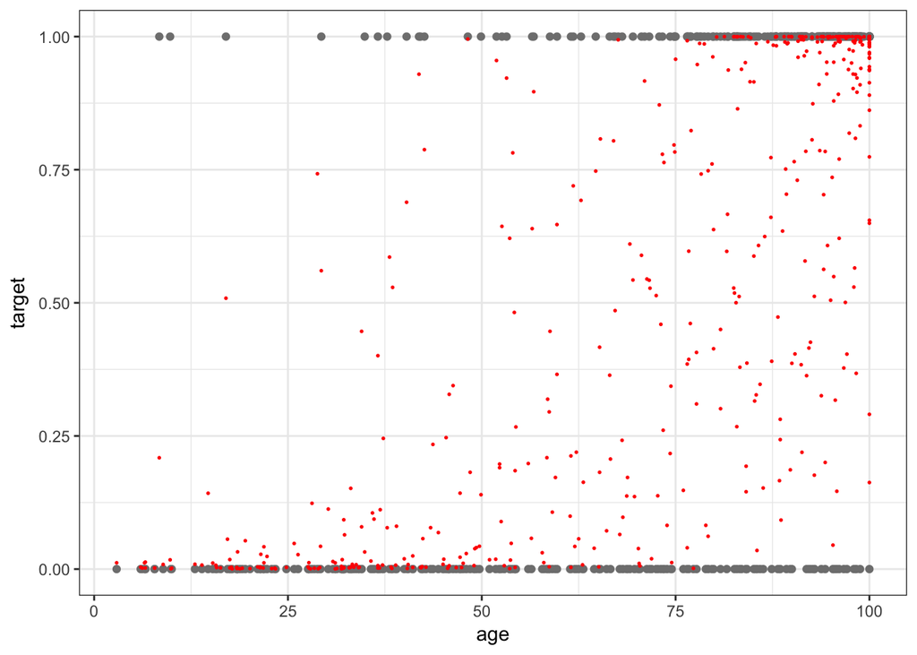

```r
#plots for Model 2
ggplot(data = train, aes(x = age, y = target)) +
    geom_point(color = 'grey50') +
    geom_point(data = train2, aes(x = age, y = pred3), color = 'red', size = 0.3) +
    theme_bw()
```

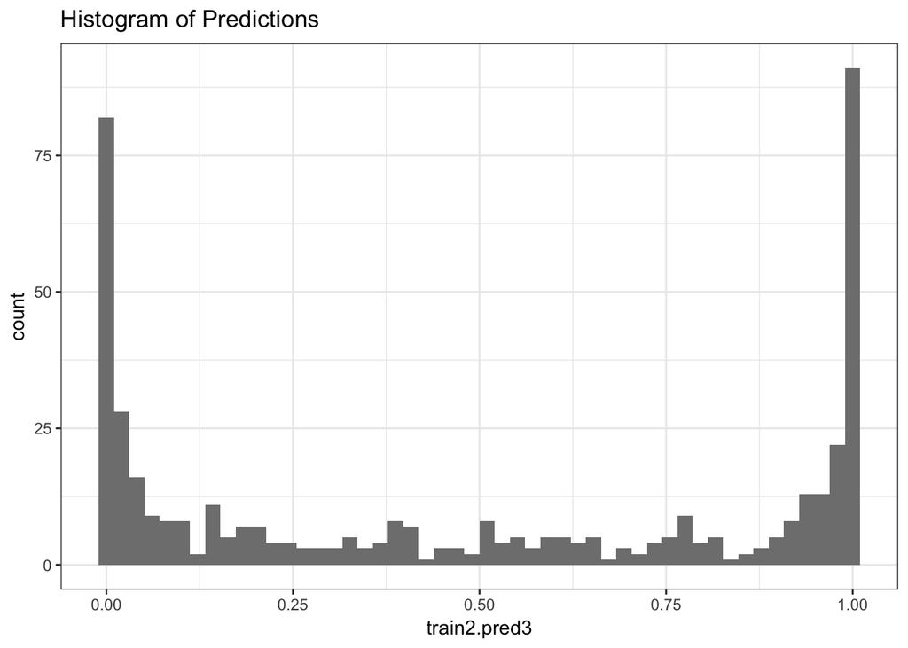

```r
data.frame(train2$pred3) %>%
    ggplot(aes(x = train2.pred3)) +
    geom_histogram(bins = 50, fill = 'grey50') +
    labs(title = 'Histogram of Predictions') +
    theme_bw()
```

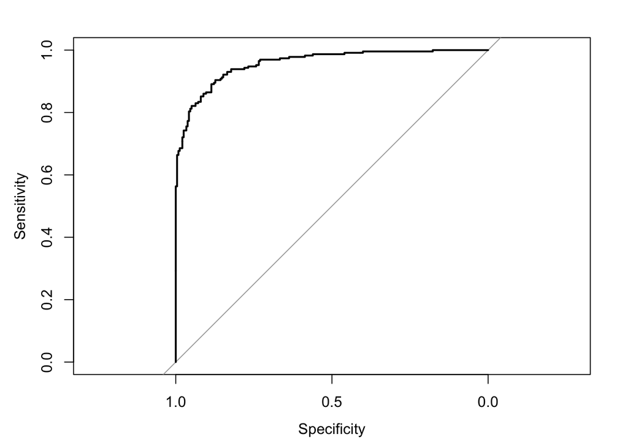

```r
plot.roc(train$target, train2$pred3)
```

```r
logit3scalar <- mean(dlogis(predict(logit3, type = "link")))
logit3scalar * coef(logit3)
```

```
##   (Intercept)            zn         indus           nox            rm
## -2.9404579504 -0.0500925172 -0.0100941744  3.6942983150 -0.0273991093
##           age           dis           tax       ptratio          medv
##  0.0025288302  0.0636293182  0.0006361103  0.0191151040  0.0124736734
##           new
## -0.0206607316
```

```r
round(logitscalar * coef(logit),2)
```

```
## (Intercept)          zn       indus        chas         nox          rm
##       -2.52       -0.05       -0.01        0.19        3.93       -0.01
##         age         dis         tax     ptratio       black       lstat
##        0.00        0.07        0.00        0.02       -0.14        0.01
##        medv         new
##        0.01       -0.03
```

```r
round(logit2scalar * coef(logit2),2)
```

```
## (Intercept)          zn       indus        chas         nox         age
##       -3.24       -0.05       -0.01        0.22        3.90        0.00
##         dis         tax     ptratio        medv         new
##        0.06        0.00        0.02        0.01       -0.02
```

```r
round(logit3scalar * coef(logit3),2)
```

```
## (Intercept)          zn       indus         nox          rm         age
##       -2.94       -0.05       -0.01        3.69       -0.03        0.00
##         dis         tax     ptratio        medv         new
##        0.06        0.00        0.02        0.01       -0.02
```

## Select Models

```r
test = read.csv(file="data/crime-evaluation-data.csv")
test2<- test
dim(test)
```

```
## [1] 40 13
```

```r
# transform data using log for skewed

test$zn <- log(test$zn+1)
test$black <- log(test$black+1)
test$chas <- log(test$chas+1)


#remove rad per correlation in prior section

test <- test[, !(colnames(test) %in% c("rad"))]

#create variable
test$new <- test$tax / (test$medv*10)

idx <- match(colist, names(test))
testNorm2 <- test[,idx]

summary(testNorm2)
```

```
##        zn             indus             chas              nox
##  Min.   :0.0000   Min.   : 1.760   Min.   :0.00000   Min.   :0.3850
##  1st Qu.:0.0000   1st Qu.: 5.692   1st Qu.:0.00000   1st Qu.:0.4713
##  Median :0.0000   Median : 8.915   Median :0.00000   Median :0.5380
##  Mean   :0.6619   Mean   :11.507   Mean   :0.03466   Mean   :0.5592
##  3rd Qu.:0.0000   3rd Qu.:18.100   3rd Qu.:0.00000   3rd Qu.:0.6258
##  Max.   :4.5109   Max.   :25.650   Max.   :0.69315   Max.   :0.7400
##       age              dis             tax           ptratio
##  Min.   :  6.80   Min.   :1.202   Min.   :188.0   Min.   :14.70
##  1st Qu.: 56.62   1st Qu.:2.041   1st Qu.:276.8   1st Qu.:18.40
##  Median : 83.25   Median :3.373   Median :307.0   Median :19.60
##  Mean   : 70.99   Mean   :3.787   Mean   :393.5   Mean   :19.12
##  3rd Qu.: 93.10   3rd Qu.:4.527   3rd Qu.:666.0   3rd Qu.:20.20
##  Max.   :100.00   Max.   :9.089   Max.   :666.0   Max.   :21.20
##       medv            new
##  Min.   : 8.40   Min.   :0.6356
##  1st Qu.:16.98   1st Qu.:1.1427
##  Median :20.55   Median :1.3538
##  Mean   :21.88   Mean   :2.2218
##  3rd Qu.:25.00   3rd Qu.:2.5804
##  Max.   :50.00   Max.   :7.9286
```

```r
modelfinal <- predict(logit2, newdata = testNorm2, type="response")

y_pred_num <- ifelse(modelfinal > 0.5, 1, 0)
y_pred <- factor(y_pred_num, levels=c(0, 1))
summary(y_pred)
```

```
##  0  1
## 21 19
```

```r
rbind(round(summary(predlogit2),4), round(summary(modelfinal),4)) %>% kable()
```

| Min. | 1st Qu. | Median | Mean | 3rd Qu. | Max. |
| --- | --- | --- | --- | --- | --- |
| 0.0002 | 0.0330 | 0.4686 | 0.4914 | 0.9663 | 1 |
| 0.0011 | 0.0515 | 0.4513 | 0.4887 | 0.9067 | 1 |